# Machine Learning for Qualitative Prediction of Weight Lifting Exercises

Tomasz Kurowski

May 9, 2016

## Executive Summary

Using [Qualitative Activity Recognition of Weight Lifting Exercises](http://groupware.les.inf.puc-rio.br/work.jsf?p1=1120) data a classification random forest is built for predicting quality of weight lifting exercises from sensor measurements.

- the data is explored and cleaned
- preliminary feature selection is performed using multinomial regression
- random forest model is fit using [`caret` package](http://topepo.github.io/caret/index.html)
- and its performance is evaluated

The full `R` source code can be found at [project’s github page](https://github.com/tkurowski/datascience-pml) and is considered an integral part of this report.

## Background

Human Activity Recognition (HAR) uses and examines data generated by personal “wearable” computers: smartphones, fitness trackers, smartwatches. Potential applications for HAR include: elderly monitoring, weight-loss programs support or digital assistance for physical exercises. Traditionally, HAR focused on identifying different types of activities; little attention was paid to the quality of performing exercises.

Velloso, E. et. al. (2013) carried out a study in which

> Six young health participants were asked to perform one set of 10 repetitions of the Unilateral Dumbbell Biceps Curl in five different fashions: exactly according to the specification (Class A), throwing the elbows to the front (Class B), lifting the dumbbell only halfway (Class C), lowering the dumbbell only halfway (Class D) and throwing the hips to the front (Class E).

> Class A corresponds to the specified execution of the exercise, while the other 4 classes correspond to common mistakes.

and using the gathered data they

> investigated qualitative activity recognition on the example of assessing the quality of execution of weight lifting exercises.

They presented their results at the 4th Augmented Human (AH) International Conference in 2013, in a research paper [Qualitative Activity Recognition of Weight Lifting Exercises](http://groupware.les.inf.puc-rio.br/work.jsf?p1=1120).

In this analysis we will use the same data set and build a classification model for predicting `classe` dependent variable using (a subset of) over 150 independed variables collected with four different sensors.

## Getting and Exploring the Data

The data comes in two sets: `pml-training.csv` and `pml-testing.csv` (without the dependent variable).

```r
library(caret)
df <- read.csv("pml-training.csv")
```

The training data contains 19622 records and 160 columns.

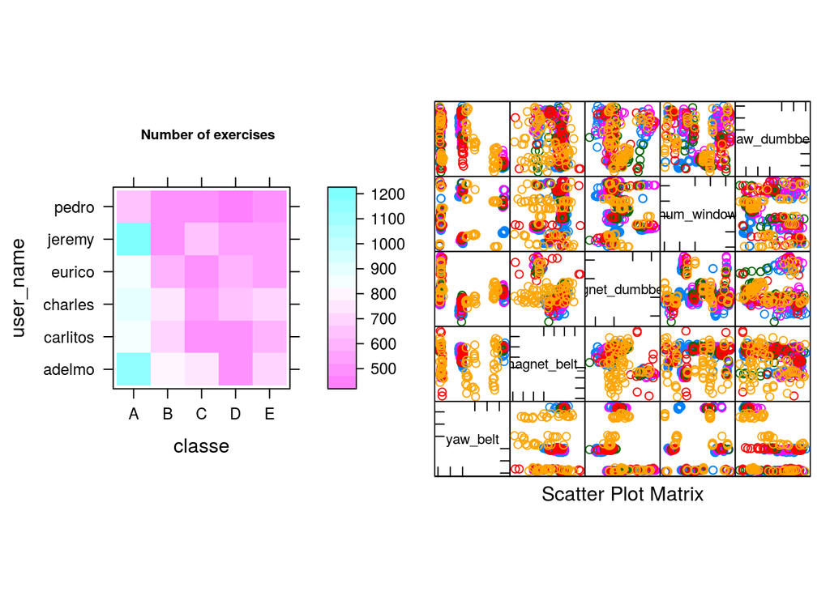

**Fig. 1.** Left: The number of exercises and the proportions of `classe` values are not constant between users. Right: Some variables chosen to train the final model. Notice that we can already see small regions of homogeneous color (`classe`). The plot was made using a 2% sample of the data.

```r
with.na <- sapply(names(df), function (n) sum(is.na(df[[n]]))) # count NA
with.na <- with.na[with.na > 0] # filter columns with NA
```

67 columns in the data are 97.9% `NA` (missing values).

##### Assessing the irrelevance of the (almost) empty columns

Being almost empty does not, by itself, make the columns useless (what if the few available values happen to determine the `classe` perfectly?). Figure 2 shows the classification tree built using the near-empty columns.

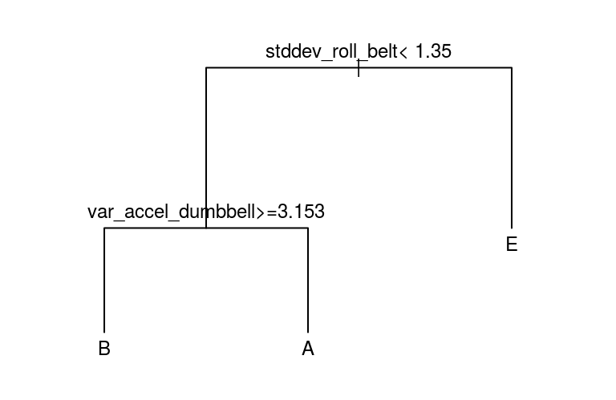

**Fig. 2.** Classification tree built with `rpart` on near-empty columns.

Only two of them are of any use and the estimated accuracy is only 0.487. Besides, the tree can only be applied to records where given columns have proper values.

## Cleaning the Data

We discard irrelevant columns. These include date and time variables, row number (`X`), `new_window` (yes-no factor that is “no” in 98% of cases) and `user_name`.

```r
irrelevant <- c(names(with.na), 'X', 'user_name', 'new_window',
                'cvtd_timestamp', 'raw_timestamp_part_1', 'raw_timestamp_part_2')
df[irrelevant] <- NULL
```

##### Is `user_name` (ir)relevant?

In theory, `user_name` might be a powerful decision variable for the data set. However, this would yield a very narrow model, unusable for greater audience.

`read.csv` coerced many variables to factors. We bring them back to their original numeric domain.

```r
# NOTE: this clean function must also be applied to the test set (for prediction)
clean <- function (df) {
    for (n in names(df))
        if (n != "classe" && class(df[[n]]) == 'factor')
            df[[n]] <- as.numeric(df[[n]])
    df
}
df <- clean(df)
```

## Partitioning

The `caret` package uses techniques like cross-validation or bagging to find the best fit; we will additionally simulate a test set to better evaluate model’s accuracy.

```r
set.seed(4321)
intr <- createDataPartition(df$classe, p=0.7, list=FALSE)
tr <- df[intr, ]
tst <- df[-intr, ]
```

## Preliminary Feature Selection

The training data now contains 13737 rows, 87 columns each. To train such a big data set (with `caret`’s built in machinery) one needs significant amount of time or computing power. We will therefore perform a very simple feature selection that will, nevertheless, turn out quite effective.

The idea is to fit a multinomial linear regression model using all variables and then select those with lowest p-values.

```r
library(nnet) # for multinom[ial] model
mnm <- multinom(classe ~ ., data = tr)
smry <- summary(mnm)
```

##### On linear model feature selection

Of course, linear model selection is an art in and of itself. What we do here is an oversimplified version of *backward stepwise selection*. What we later call “best” or “top” variables might be far from being good at all. They do work all right in this particular case, i.e. they lead to a highly accurate model of significantly reduced size.

We compute z-value, and associated p-values for each variable. We then order the variables by p-values (smallest first).

```r
z <- smry$coefficients / smry$standard.errors
p <- (1 - pnorm(abs(z))) * 2; # 2-tail
p <- p[,-1]                   # ignore intercept
p <- sort(apply(p, 2, sum))   # best features first
```

The righ-hand panel of figure 1 presents a scatter plot matrix of 5 (of 20) variables that will be used to train the final model.

## Training a Random Forest Model

We choose 20 “best” variables and fit a random forest model using k-fold cross-validation, k = 5.

```r
set.seed(2704)
mrf <- train(classe ~ ., trControl = trainControl(method='cv', number=5),
             data = tr[, c('classe', names(p[1:20]))], # 20 'best' features
             method = "rf")
# Now go, make yourself a cup of coffee!
```

```
Random Forest

13737 samples
   20 predictors
    5 classes: 'A', 'B', 'C', 'D', 'E'

No pre-processing
Resampling: Cross-Validated (5 fold)
Summary of sample sizes: 10989, 10990, 10989, 10990, 10990
Resampling results across tuning parameters:

  mtry  Accuracy   Kappa
   2    0.9946130  0.9931854
  11    0.9965785  0.9956720
  20    0.9949771  0.9936463

Accuracy was used to select the optimal model using  the largest value.
The final value used for the model was mtry = 11.
```

Model’s expected accuracy (estimated with 5-fold cross-validation) is 0.9966 (see figure 3).

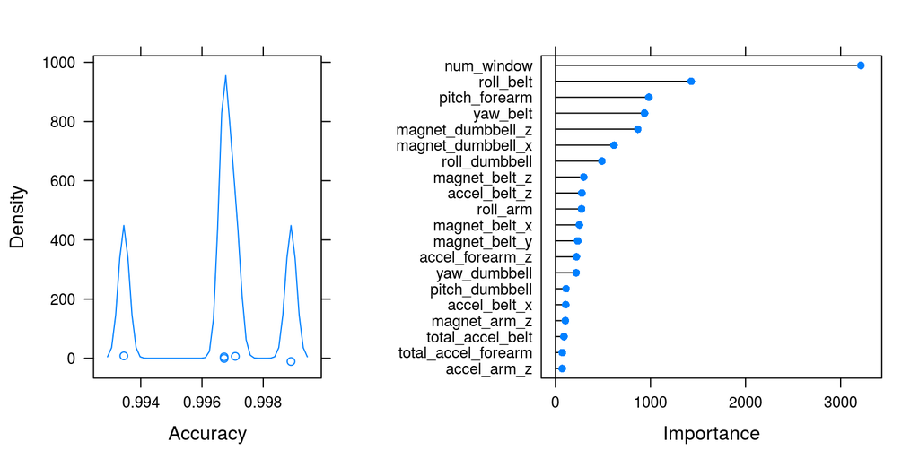

**Fig. 3.** Left: within-model accuracy distribution. The expected value is 0.9966. Right: variables’ importance computed as the mean decrease in node impurity (gini index).

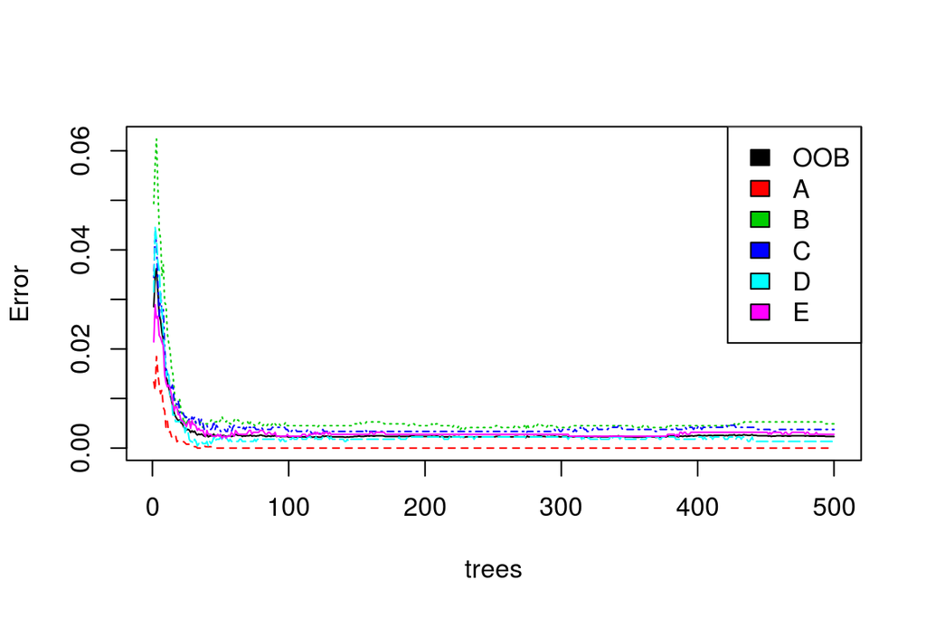

**Fig. 4.** Error rate (per class and “out-of-bag”) as a function of number of trees. It decreases quickly (until the number of trees is about 50), and then stabilizes below 0.01.

## Testing the Model

```r
confusionMatrix(predict(mrf, tst), tst$classe)
```

```
Confusion Matrix and Statistics

          Reference
Prediction    A    B    C    D    E
         A 1674    3    0    0    0
         B    0 1136    0    0    1
         C    0    0 1026    1    0
         D    0    0    0  963    8
         E    0    0    0    0 1073

Overall Statistics

               Accuracy : 0.9978
                 95% CI : (0.9962, 0.9988)
    No Information Rate : 0.2845
    P-Value [Acc > NIR] : < 2.2e-16

                  Kappa : 0.9972
 Mcnemar's Test P-Value : NA

Statistics by Class:

                     Class: A Class: B Class: C Class: D Class: E
Sensitivity            1.0000   0.9974   1.0000   0.9990   0.9917
Specificity            0.9993   0.9998   0.9998   0.9984   1.0000
Pos Pred Value         0.9982   0.9991   0.9990   0.9918   1.0000
Neg Pred Value         1.0000   0.9994   1.0000   0.9998   0.9981
Prevalence             0.2845   0.1935   0.1743   0.1638   0.1839
Detection Rate         0.2845   0.1930   0.1743   0.1636   0.1823
Detection Prevalence   0.2850   0.1932   0.1745   0.1650   0.1823
Balanced Accuracy      0.9996   0.9986   0.9999   0.9987   0.9958
```

The accuracy of test set prediction is 0.9978. And, indeed, applied onto the “true” test set (20 examples without `classe` label in `pml-testing.csv`) the model achieved 100% accuracy.

## Conclusion

*Random forest* is ineed a powerful technique. It is hardly surprising that it was chosen as the default method of the `caret` packages’s `train` function. Many other parameters were also left to their default values, and the final model’s good results are proof of great knowledge and experience of the package authors.

Simplified feature (pre)selection with multinomial regression was an experiment aimed only at saving time. It did work well and seemingly did not (much) affect accuracy.

## References

1. Velloso, E.; Bulling, A.; Gellersen, H.; Ugulino, W.; Fuks, H. [Qualitative Activity Recognition of Weight Lifting Exercises](http://groupware.les.inf.puc-rio.br/work.jsf?p1=1120). Proceedings of 4th International Conference in Cooperation with SIGCHI (Augmented Human ’13). Stuttgart, Germany: ACM SIGCHI, 2013.
2. [`caret` package documentation](http://topepo.github.io/caret/index.html)
3. Gareth James, Daniela Witten, Trevor Hastie and Robert Tibshirani, [An Introduction to Statistical Learning](http://www-bcf.usc.edu/~gareth/ISL/)